# ExtraaLearn Project

### **Observation**

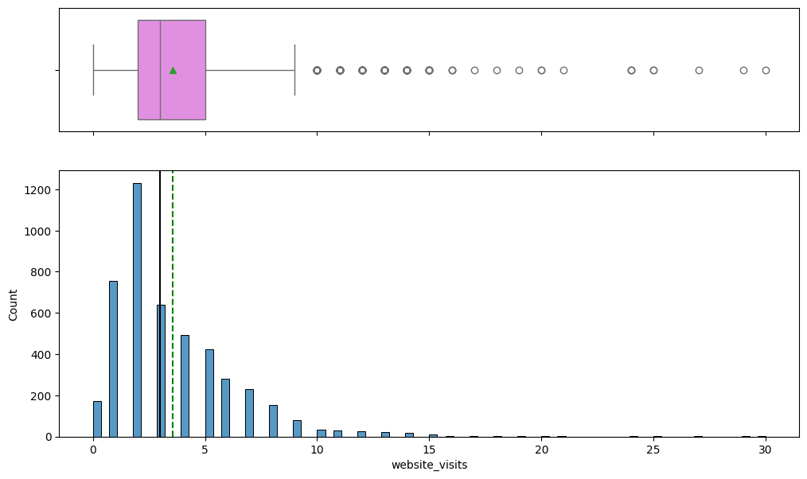

```python
plot(data, "website_visits") # plots for website_visits using 'plot' function
```

### **Observation**

- The distribution is heavily right-skewed, with a large concentration of leads having a low number of website visits. The histogram shows the highest bars for 0-5 visits, indicating that most leads visit the website only a few times.
- There's a sharp decline in frequency as the number of visits increases. After about 10 visits, the number of leads drops significantly, with very few leads having more than 15 visits.
- The box plot at the top shows that the median is quite low, likely around 2-3 visits. The box itself is very compact, suggesting that the interquartile range is narrow. There are numerous outliers extending far to the right, indicating some leads with a much higher number of visits than typical.

```python
data[data["website_visits"] == 0]. shape # Check the number of leads  who did not visit web-site
```

```
(174, 14)
```

### Observation

There are 174 records in the dataset where the "website_visits" column is equal to 0. This means that 174 leads did not visit the web-site at all.

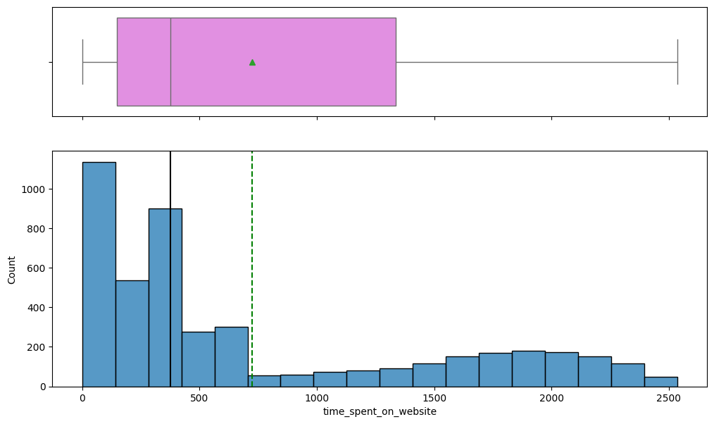

```python
plot(data, "time_spent_on_website") #plots for time_spent_on_website using 'plot' function
```

### **Obervation**

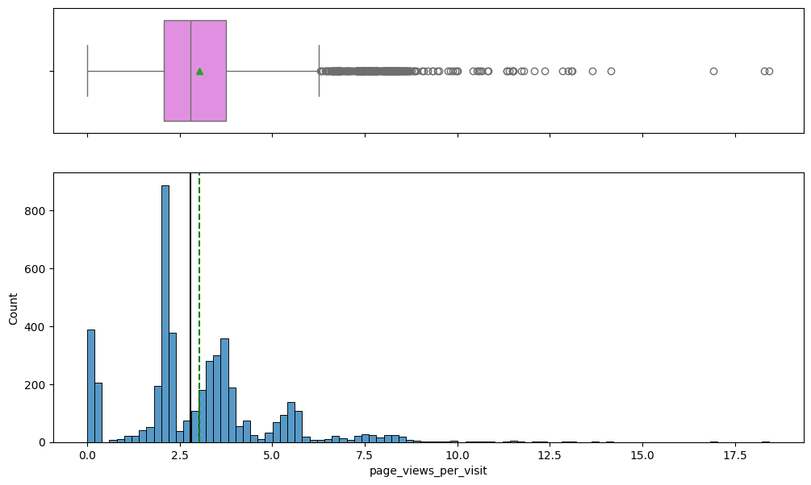

```python
plot(data, "page_views_per_visit") #plots for page_views_per_visit using 'plot' function
```

### **Observation**

- The distribution is right-skewed, with a concentration of data points in the lower range of page views per visit. There's a notable peak around 2-4 page views per visit, which appears to be the most common behavior.
- The box plot at the top shows that the median is relatively low, likely around 2-3 page views per visit. The box itself is compact, indicating that the middle 50% of the data falls within a narrow range.
- There are numerous outliers (represented by circles) extending far to the right on the box plot, suggesting that while most visits involve relatively few page views, there are some instances of much higher engagement with many page views per visit.

```python
#function to create labeled barplot
def labeledBarplot(data, feature, perc = False, n = None):
    total = len(data[feature]) # Column length
    count = data[feature].nunique()
    if n is None:
        plt.figure(figsize = (count + 1, 5))
    else:
        plt.figure(figsize = (n + 1, 5))

    plt.xticks(rotation = 90, fontsize = 16)
    ax = sns.countplot(data, x = feature, palette = "Paired",
                       order = data[feature].value_counts().index[:n].sort_values())

    for p in ax.patches:
        if perc == True:
            label = "{:.1f}%".format(100 * p.get_height()/total) #percentage of each class of the category
        else:
            label = p.get_height() #Count of each level of the category
        x = p.get_x() + p.get_width() / 2 # width of the plot
        y = p.get_height() # height of the plot

        ax.annotate(label, (x, y), ha = "center", va = "center",
                     size = 12, xytext= (0, 5), textcoords = "offset points") #annotate the percentage
        plt.show() # show the plot
```

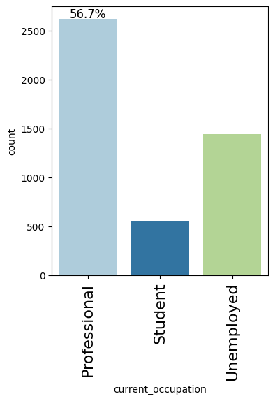

```
current_occupation
Professional    0.567216
Unemployed      0.312446
Student         0.120338
Name: proportion, dtype: float64
```

```python
labeledBarplot(data, "current_occupation", perc = True) #Plot the labeled barplot for current_occupation
data['current_occupation'].value_counts(normalize = True)
```

### **Observation**

- The chart displays three categories of current occupation: Professional, Student, and Unemployed. Professionals form the largest group, making up 56.7% of the leads. This is clearly indicated by the highest bar and the percentage label.
- Unemployed individuals form the second largest group, represented by a substantial green bar. Students comprise the smallest group among the leads, shown by the shortest blue bar.

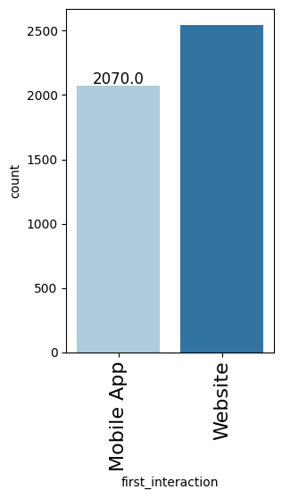

```
first_interaction
Website       0.551171
Mobile App    0.448829
Name: proportion, dtype: float64
```

```python
labeledBarplot(data, "first_interaction") # Labeled barplot for first_interaction
data['first_interaction'].value_counts(normalize = True)
```

### **Observation**

- The chart displays two categories for first interaction: Mobile App, and Website. Larger group of around 2500 first Encountered with Website.
- Group if 2070 members have interacted with Mobile App.

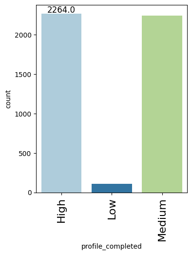

```
profile_completed
High      0.490893
Medium    0.485906
Low       0.023200
Name: proportion, dtype: float64
```

```python
labeledBarplot(data, "profile_completed") #Labeled barplot for profile_completed
data['profile_completed'].value_counts(normalize = True)
```

### **Observation**

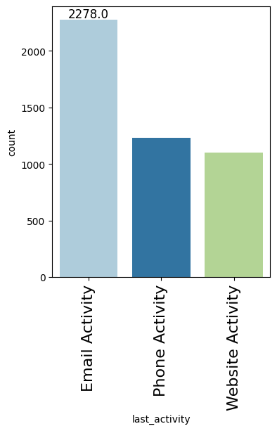

```
last_activity
Email Activity      0.493929
Phone Activity      0.267563
Website Activity    0.238508
Name: proportion, dtype: float64
```

```python
labeledBarplot(data, "last_activity") # Labeled barplot for last_activity
data['last_activity'].value_counts(normalize = True)
```

### **Obeservation**

- Email activity is the most frequent last activity, with a count of 2278, higher than the other two categories.
- Phone activity is the second most frequent last activity with the count ranging between 1000 and 1500.
- Website activity is the least frequent last activity among the three categories with count around 1000.

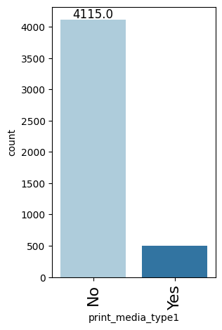

```
print_media_type1
No     0.892238
Yes    0.107762
Name: proportion, dtype: float64
```

```python
labeledBarplot(data, "print_media_type1") #Labeled barplot for print_media_type1
data['print_media_type1'].value_counts(normalize = True)
```

### **Observation**

- A vast majority of leads (approximately 89%) did not see the ad of ExtraaLearn in the newspaper. Only a small percentage of leads (approximately 11%) were exposed to ExtraaLearn's newspaper advertisement.
- This suggests that print media (newspapers) might not be a very effective channel for reaching potential leads for ExtraaLearn.

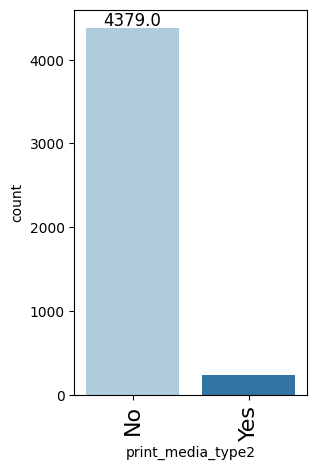

```
print_media_type2
No     0.94948
Yes    0.05052
Name: proportion, dtype: float64
```

```python
labeledBarplot(data, "print_media_type2") #Labeled barplot for print_media_type2
data['print_media_type2'].value_counts(normalize = True)
```

### **Observations**

- A vast majority of leads (approximately 95%) did not see the ad of ExtraaLearn in the magazine. Only a small percentage of leads (approximately 5%) were exposed to ExtraaLearn's magazine advertisement.
- This suggests that print media (magazines) might not be a very effective channel for reaching potential leads for ExtraaLearn.

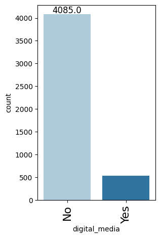

```
digital_media
No     0.885733
Yes    0.114267
Name: proportion, dtype: float64
```

```python
labeledBarplot(data, "digital_media") #Labeled barplot for digital_media
data['digital_media'].value_counts(normalize = True)
```

### **Observation**

- A vast majority of leads (approximately 89%) did not see the ad of ExtraaLearn on digital platforms. Only a small percentage of leads (approximately 11%) were exposed to ExtraaLearn's digital advertisement.
- This suggests that digital media might not be a very effective channel for reaching potential leads for ExtraaLearn

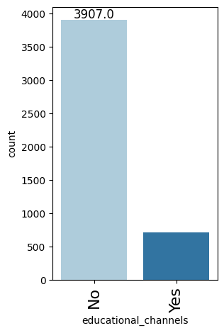

```
educational_channels
No     0.847138
Yes    0.152862
Name: proportion, dtype: float64
```

```python
labeledBarplot(data, "educational_channels") #Labeled barplot for educational_channels
data['educational_channels'].value_counts(normalize = True)
```

### **Observation**

- A vast majority of leads (approximately 85%) did not hear about ExtraaLearn through educational channels.
- Only a small percentage of leads (approximately 15%) were exposed to ExtraaLearn through educational channels.
- This suggests that educational channels might not be a very effective channel for reaching potential leads for ExtraaLearn.

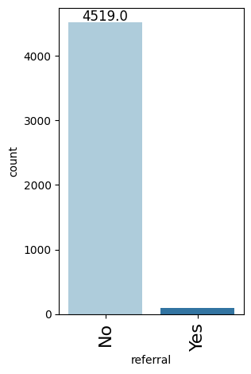

```
referral
No     0.979835
Yes    0.020165
Name: proportion, dtype: float64
```

```python
labeledBarplot(data, "referral") # Labeled barplot for referral
data['referral'].value_counts(normalize = True)
```

### **Observation**

- A vast majority of leads (approximately 98%) did not hear about ExtraaLearn through referrals. Only a small percentage of leads (approximately 2%) were exposed to ExtraaLearn through referrals.
- This suggests that referrals might not be an effective channel for reaching potential leads for ExtraaLearn

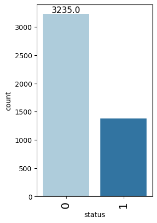

```
status
0    0.701431
1    0.298569
Name: proportion, dtype: float64
```

```python
labeledBarplot(data, "status") # Labeled barplot for status
data['status'].value_counts(normalize=True)
```

### **Observations**

- The vast majority of leads (approximately 70%) did not convert to paid customers (status = 0). Only a small percentage of leads (approximately 30%) converted to paid customers (status = 1).
- This indicates a relatively low conversion rate, suggesting that ExtraaLearn may need to optimize its lead nurturing and conversion strategies.

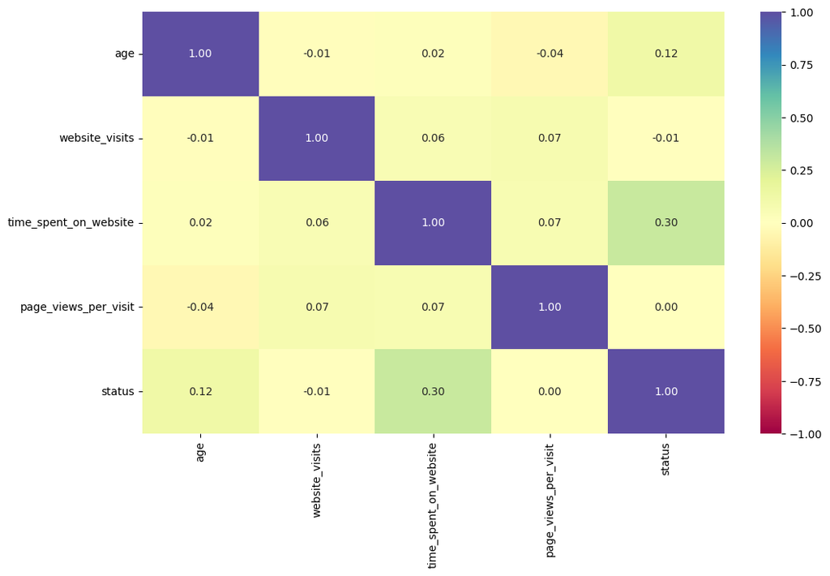

```python
cols_list = data.select_dtypes(include = np.number).columns.tolist()
plt.figure(figsize = (12, 7))
sns.heatmap(data[cols_list].corr(), annot=True, vmin=-1, vmax=1, fmt=".2f", cmap="Spectral")
plt.show()
```

### **Observation**

- `status` and `age` have a week positive correlation, which suggests that there might be a slightly higher tendency for older leads to convert into paid customers compared to younger leads.
- `time_spent_on_website` and status are positively correlated, suggesting that leads who spend more time on the website are more likely to convert into paid customers.
- No other variables have a high correlation among them

```python
# Function to plot distribution with respect to target

def distrPlotWrtTarget (data, predictor, target):

    fig, axs = plt.subplots(2, 2, figsize = (12, 10))
    targetUniq = data[target].unique()

    axs[0, 0].set_title("Distribution of target for target=" + str(targetUniq[0]))
    sns.histplot(
        data = data[data[target] == targetUniq[0]], x = predictor,
        kde = True, ax = axs[0, 0], color = "teal", stat = "density",
        )

    axs[0, 1].set_title("Distribution of target for target = " + str(targetUniq[1]))
    sns.histplot(
        data = data[data[target] == targetUniq[1]], x = predictor,
        kde = True, ax = axs[0, 1], color = "orange", stat = "density"
    )

    axs[1, 0].set_title("Boxplot wrt target")
    sns.boxplot(data = data, x = target, y = predictor, ax = axs[1, 0], palette= "gist_rainbow")

    axs[1, 1].set_title("Boxplot (without outliers) w.r.t target")
    sns.boxplot(data = data, x = target, y = predictor, ax = axs[1, 1],
                showfliers = False, palette = "gist_rainbow")

    plt.tight_layout()
    plt.show()
```

```python
def stackedBarplot(data, predictor, target):

    count = data[predictor].nunique()
    sorter = data[target].value_counts().index[-1]
    tab1 = pd.crosstab(data[predictor], data[target], margins = True).sort_values(by = sorter, ascending = False)
    print(tab1)
    print("-" * 120)
    tab = pd.crosstab(data[predictor], data[target], normalize = "index").sort_values(by = sorter, ascending = False)
    tab.plot(kind="bar", stacked=True, figsize=(count + 5, 5))
    plt.legend(loc="lower left", frameon=False)
    plt.legend(loc="upper left", bbox_to_anchor=(1, 1))
    plt.show()
```

```
status                 0     1   All
current_occupation
All                 3235  1377  4612
Professional        1687   929  2616
Unemployed          1058   383  1441
Student              490    65   555
------------------------------------------------------------------------------------------------------------------------
```

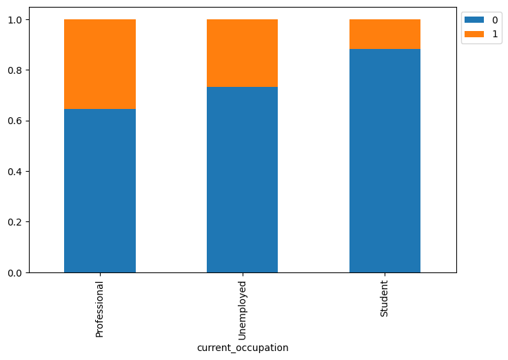

```python
stackedBarplot(data, "current_occupation", "status")
```

### **Observation**

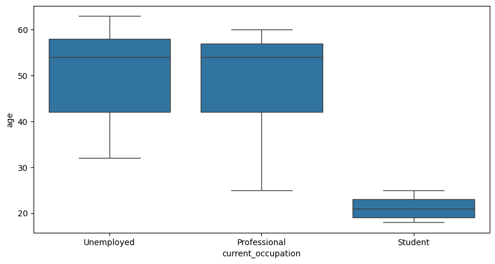

```python
plt.figure(figsize = (10, 5))
sns.boxplot(data = data, x = data["current_occupation"], y = data["age"])
plt.show()
```

### **Observation**

```python
data.groupby(["current_occupation"])["age"].describe()
```

| current_occupation | count | mean | std | min | 25% | 50% | 75% | max |
| --- | --- | --- | --- | --- | --- | --- | --- | --- |
| Professional | 2616.0 | 49.347477 | 9.890744 | 25.0 | 42.0 | 54.0 | 57.0 | 60.0 |
| Student | 555.0 | 21.144144 | 2.001114 | 18.0 | 19.0 | 21.0 | 23.0 | 25.0 |
| Unemployed | 1441.0 | 50.140180 | 9.999503 | 32.0 | 42.0 | 54.0 | 58.0 | 63.0 |

```
status                0     1   All
first_interaction
All                3235  1377  4612
Website            1383  1159  2542
Mobile App         1852   218  2070
------------------------------------------------------------------------------------------------------------------------
```

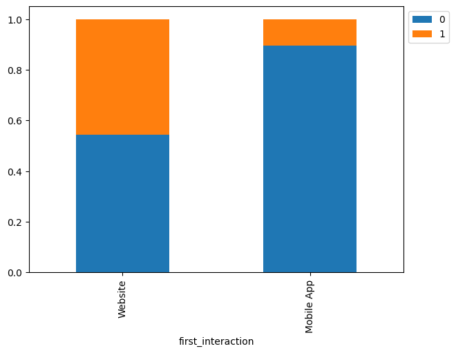

```python
stackedBarplot(data, "first_interaction", "status") # Stacked barplot for first_interaction and status
```

### **Observation**

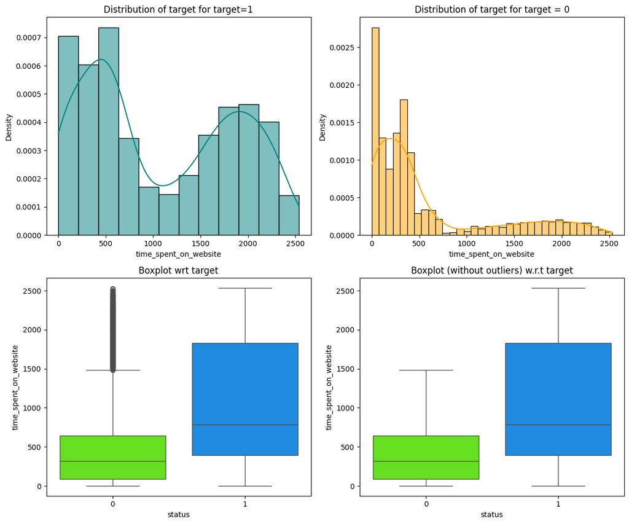

```python
distrPlotWrtTarget(data, "time_spent_on_website", "status") # targeted plots for time_spent_on_Website and status
```

### **Observation**

```python
data.groupby(["status"])["time_spent_on_website"].median() # median for time_spent_on_website and status
```

```
status
0    317.0
1    789.0
Name: time_spent_on_website, dtype: float64
```

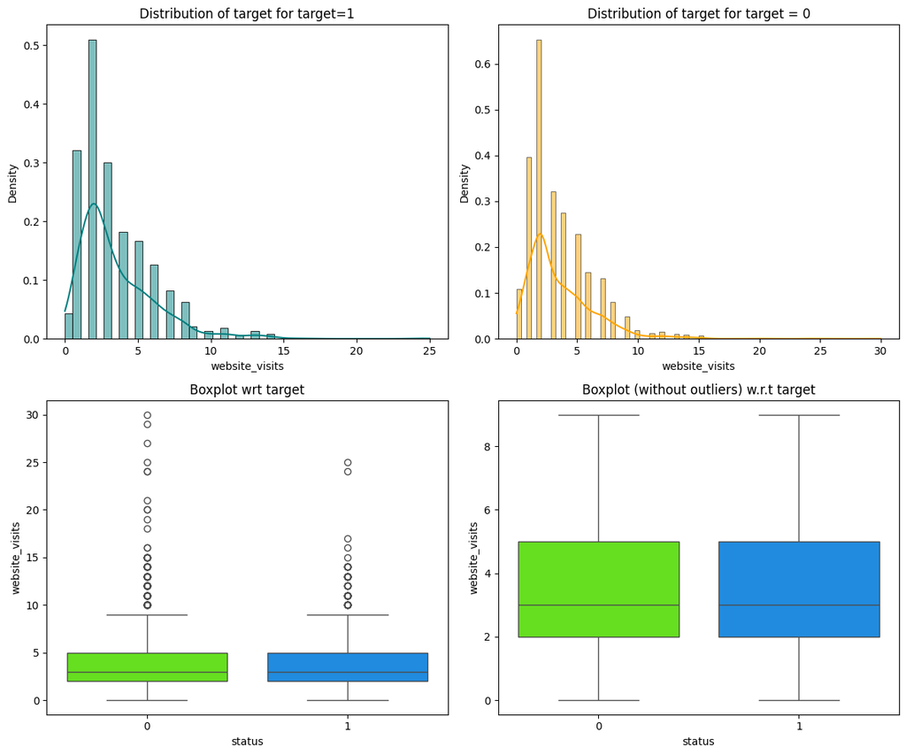

```python
distrPlotWrtTarget(data, "website_visits", "status") # plots distribution for website_visits and status
```

### **Observation**

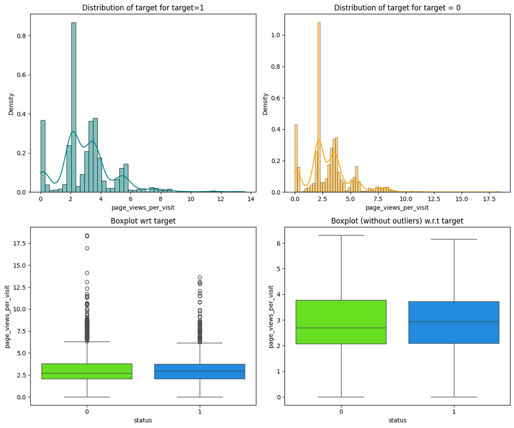

```python
distrPlotWrtTarget(data, "page_views_per_visit", "status") # distributed plots for page_views_per_visit and status
```

```
status                0     1   All
profile_completed
All                3235  1377  4612
High               1318   946  2264
Medium             1818   423  2241
Low                  99     8   107
------------------------------------------------------------------------------------------------------------------------
```

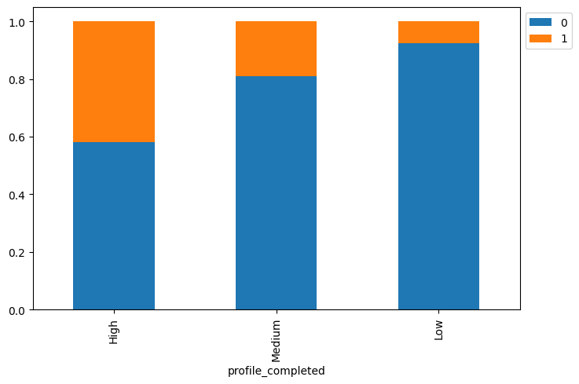

```python
stackedBarplot(data, "profile_completed", "status") #Stacked barplot for profile_completed and status
```

### **Observation**

- High Profile Completion: Leads with high profile completion have the highest conversion rate (approximately 42%). This suggests that users who invest time in providing detailed information are more likely to become paying customers.
- Medium Profile Completion: This group has a moderate conversion rate (approximately 19%). While lower than the high completion group, it still represents a significant portion of conversions.
- Low Profile Completion: The conversion rate for low profile completion is extremely low (approximately 7%). This indicates that users who provide minimal information are less likely to convert.

```
status               0     1   All
last_activity
All               3235  1377  4612
Email Activity    1587   691  2278
Website Activity   677   423  1100
Phone Activity     971   263  1234
------------------------------------------------------------------------------------------------------------------------
```

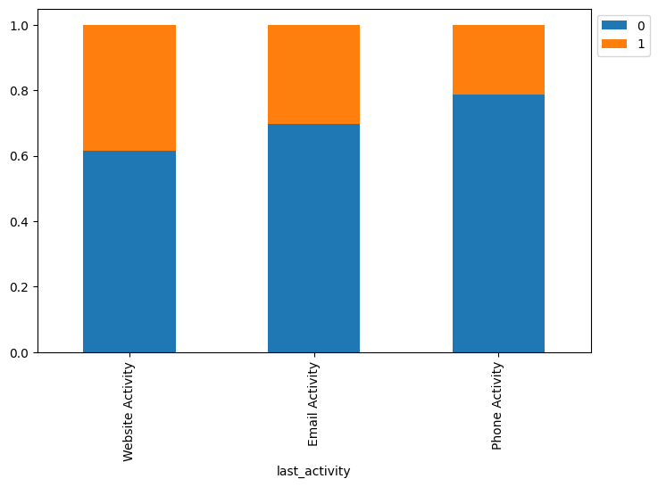

```python
stackedBarplot(data, "last_activity", "status") # Stacked Barplot for last_activity and status
```

### **Observation**

```
status                0     1   All
print_media_type1
All                3235  1377  4612
No                 2897  1218  4115
Yes                 338   159   497
------------------------------------------------------------------------------------------------------------------------
```

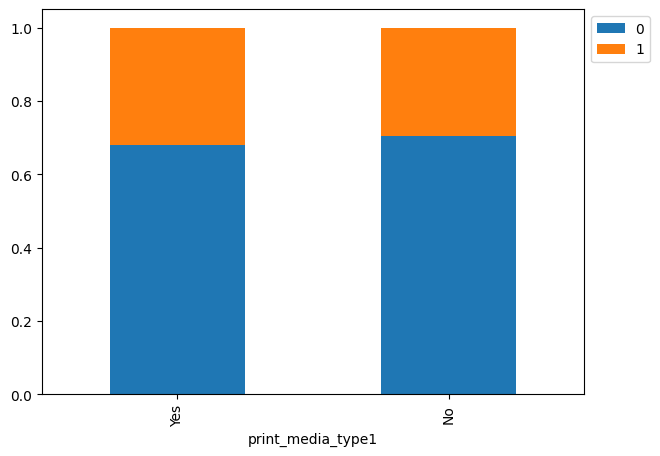

```python
stackedBarplot(data, "print_media_type1", "status") # Stacked barplot for print_media_type1 and status
```

### **Observation**

```
status                0     1   All
print_media_type2
All                3235  1377  4612
No                 3077  1302  4379
Yes                 158    75   233
------------------------------------------------------------------------------------------------------------------------
```

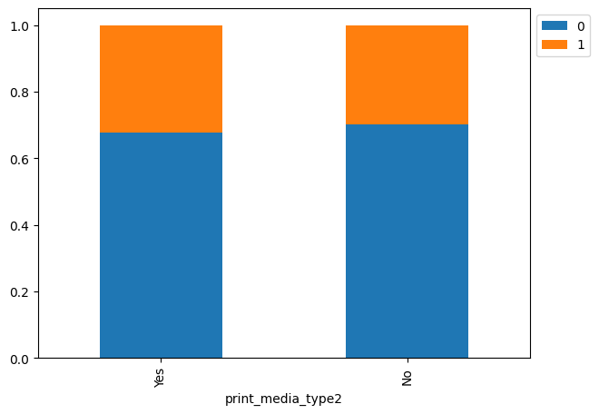

```python
stackedBarplot(data, "print_media_type2", "status") # Stacked barplot for print_media_type2 and status
```

### **Observation**

```
status            0     1   All
digital_media
All            3235  1377  4612
No             2876  1209  4085
Yes             359   168   527
------------------------------------------------------------------------------------------------------------------------
```

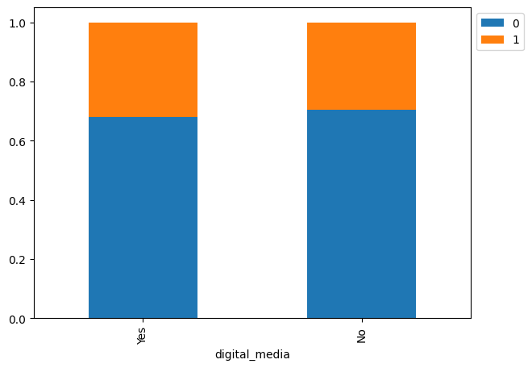

```python
stackedBarplot(data, "digital_media", "status") # Stacked barplot for digital media and status
```

### **Observation**

```
status                   0     1   All
educational_channels
All                   3235  1377  4612
No                    2727  1180  3907
Yes                    508   197   705
------------------------------------------------------------------------------------------------------------------------
```

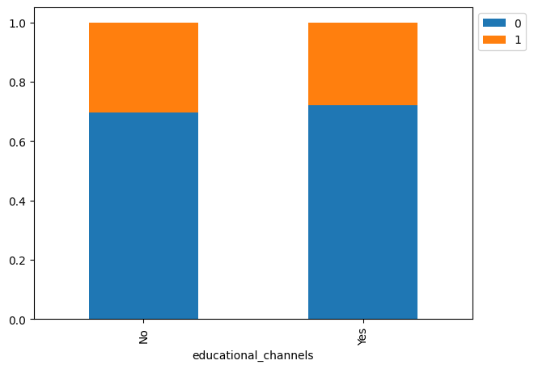

```python
stackedBarplot(data, "educational_channels", "status") # Stacked barplot for educational_channels and status
```

### **Observation**

```
status       0     1   All
referral
All       3235  1377  4612
No        3205  1314  4519
Yes         30    63    93
------------------------------------------------------------------------------------------------------------------------
```

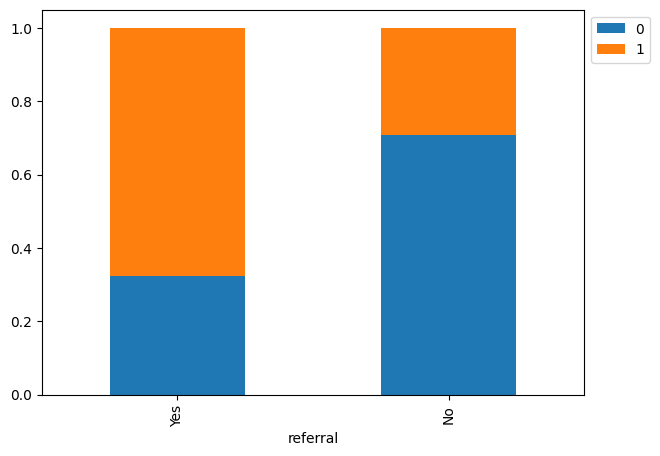

```python
stackedBarplot(data, "referral", "status") #Stacked barplot for referral and status
```

### Obesrvations

- There's a significant difference in conversion rates between the two groups. The orange segment representing conversions (status = 1) is much larger for the "Yes" (referred) group compared to the "No" (not referred) group.
- While the number of leads who were referred (Yes) is significantly smaller than those who were not referred (No), the conversion rate for the "Yes" group is dramatically higher. This strongly suggests that referrals are highly effective in generating leads who are more likely to convert.
- The overall conversion rate is relatively low, but the impact of referrals is substantial. The chart highlights the importance of referral programs in increasing the likelihood of lead conversion.

## Data Preprocessing

- Missing value treatment (if needed)
- Feature engineering (if needed)
- Outlier detection and treatment (if needed)
- Preparing data for modeling
- Any other preprocessing steps (if needed)

```python
df = data.copy() # Create the copy of the DataFrame
```

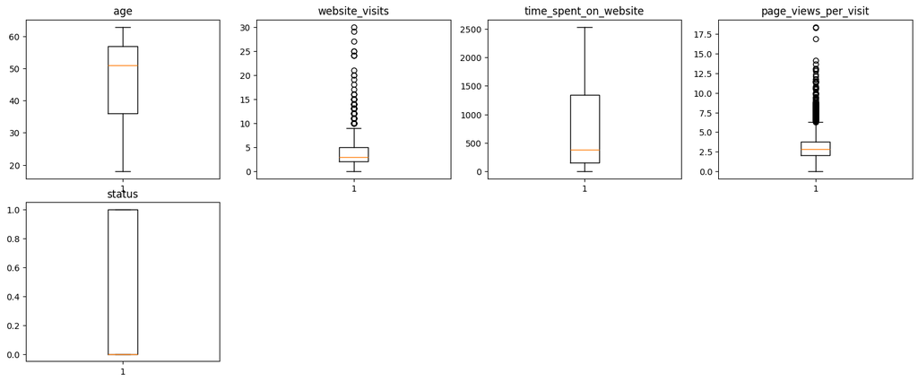

```python
# Find the outliers using boxplot
numeric_columns = data.select_dtypes(include = np.number).columns.tolist()

plt.figure(figsize = (15, 12))

for i, variable in enumerate(numeric_columns):
    plt.subplot(4, 4, i + 1)
    plt.boxplot(data[variable], whis = 1.5)
    plt.tight_layout()
    plt.title(variable)

plt.show()
```

```python
# Prepare the feature matrix X by dropping the target variable 'status'
X = data.drop(["status"], axis=1)
# Prepare the target variable Y
Y = data["status"]

# Perform one-hot encoding on categorical variables in X
X = pd.get_dummies(X, drop_first = True)

# Splitting the data in 70:30 ratio for train to test data
X_train, X_test, y_train, y_test = train_test_split(X, Y, test_size = 0.30, random_state = 1)
```

```python
# Checking that no column has missing values in train or test sets
print(X_train.isna().sum())
print('-'*30)
print(X_test.isna().sum())
```

```
age                               0
website_visits                    0
time_spent_on_website             0
page_views_per_visit              0
current_occupation_Student        0
current_occupation_Unemployed     0
first_interaction_Website         0
profile_completed_Low             0
profile_completed_Medium          0
last_activity_Phone Activity      0
last_activity_Website Activity    0
print_media_type1_Yes             0
print_media_type2_Yes             0
digital_media_Yes                 0
educational_channels_Yes          0
referral_Yes                      0
dtype: int64
------------------------------
age                               0
website_visits                    0
time_spent_on_website             0
page_views_per_visit              0
current_occupation_Student        0
current_occupation_Unemployed     0
first_interaction_Website         0
profile_completed_Low             0
profile_completed_Medium          0
last_activity_Phone Activity      0
last_activity_Website Activity    0
print_media_type1_Yes             0
print_media_type2_Yes             0
digital_media_Yes                 0
educational_channels_Yes          0
referral_Yes                      0
dtype: int64
```

```python
print("Shape of Training set : ", X_train.shape)
print("Shape of test set : ", X_test.shape)
print("Percentage of classes in training set: ")
print(y_train.value_counts(normalize=True))
print("Percentage of classes in test set:")
print(y_test.value_counts(normalize=True))
```

```
Shape of Training set :  (3228, 16)
Shape of test set :  (1384, 16)
Percentage of classes in training set:
status
0    0.704151
1    0.295849
Name: proportion, dtype: float64
Percentage of classes in test set:
status
0    0.695087
1    0.304913
Name: proportion, dtype: float64
```

## EDA

- It is a good idea to explore the data once again after manipulating it.

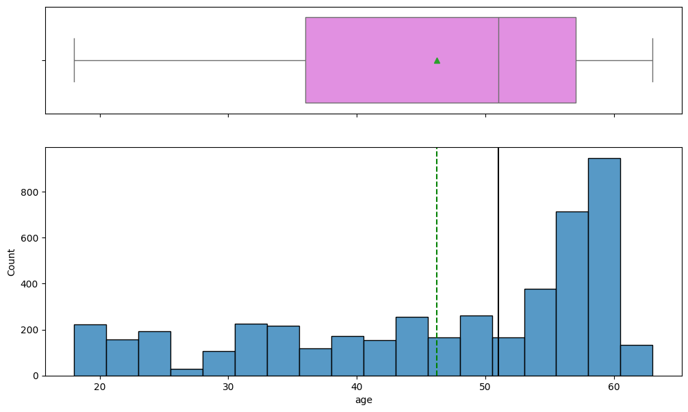

```python
plot(X, "age")
```

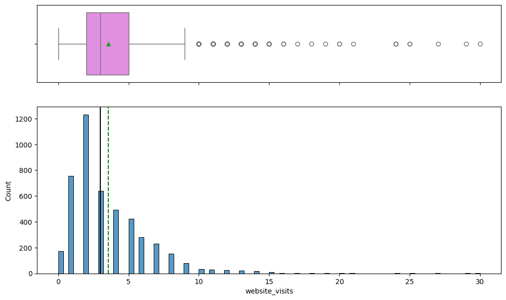

```python
plot(X, "website_visits")
```

```python
X[X["website_visits"] == 0].shape # Check the number of leads  who did not visit web-site (post data manipulation)
```

```
(174, 16)
```